# Walmart

```python
import pandas as pd
import numpy as np
import matplotlib.pyplot as plt
import seaborn as sns
```

```python
data = pd.read_csv('walmart_data.csv')
```

```python
data.head()
```

|  | User_ID | Product_ID | Gender | Age | Occupation | City_Category | Stay_In_Current_City_Years | Marital_Status | Product_Category | Purchase |
| --- | --- | --- | --- | --- | --- | --- | --- | --- | --- | --- |
| 0 | 1000001 | P00069042 | F | 0-17 | 10 | A | 2 | 0 | 3 | 8370 |
| 1 | 1000001 | P00248942 | F | 0-17 | 10 | A | 2 | 0 | 1 | 15200 |
| 2 | 1000001 | P00087842 | F | 0-17 | 10 | A | 2 | 0 | 12 | 1422 |
| 3 | 1000001 | P00085442 | F | 0-17 | 10 | A | 2 | 0 | 12 | 1057 |
| 4 | 1000002 | P00285442 | M | 55+ | 16 | C | 4+ | 0 | 8 | 7969 |

# Walmart

## Walmart is an American multinational retail corporation that operates a chain of supercenters, discount departmental stores, and grocery stores from the United States. Walmart has more than 100 million customers worldwide.

## 📃 Features of the dataset:

| Feature | Description |
| --- | --- |
| User_ID | User ID of the Customer |
| Product ID | Product ID of the Purchased Product |
| Gender | Gender of the Customer (Male/Female) |
| Age | Age of the Customer (in bins) |
| Occupation | Occupation of the Customer (Masked) |
| City_Category | Category of the City (A,B,C) |
| StayInCurrentCityYears | Number of years stay in current city |
| Marital_Status | Marital Status (0 - Unmarried / 1 - Married) |
| ProductCategory | Product Category (Masked) |
| Purchase | Purchase Amount |

## Exploratory Data Analysis

```python
data.info()
```

```
<class 'pandas.core.frame.DataFrame'>
RangeIndex: 550068 entries, 0 to 550067
Data columns (total 10 columns):
 #   Column                      Non-Null Count   Dtype
---  ------                      --------------   -----
 0   User_ID                     550068 non-null  int64
 1   Product_ID                  550068 non-null  object
 2   Gender                      550068 non-null  object
 3   Age                         550068 non-null  object
 4   Occupation                  550068 non-null  int64
 5   City_Category               550068 non-null  object
 6   Stay_In_Current_City_Years  550068 non-null  object
 7   Marital_Status              550068 non-null  int64
 8   Product_Category            550068 non-null  int64
 9   Purchase                    550068 non-null  int64
dtypes: int64(5), object(5)
memory usage: 42.0+ MB
```

```python
data.shape
```

```
(550068, 10)
```

```python
print(f"TOTAL ROWS : {data.shape[0]}")
print(f"TOTAL COLUMNS : {data.shape[1]}")
```

```
TOTAL ROWS : 550068
TOTAL COLUMNS : 10
```

```python
print(f"SIZE OF DataFrame : {data.size}")
```

```
SIZE OF DataFrame : 5500680
```

```python
print(f"Index of the DataFrame : {data.index}")
```

```
Index of the DataFrame : RangeIndex(start=0, stop=550068, step=1)
```

```python
print(f"Coulumns : {data.columns}")
```

```
Coulumns : Index(['User_ID', 'Product_ID', 'Gender', 'Age', 'Occupation', 'City_Category',
       'Stay_In_Current_City_Years', 'Marital_Status', 'Product_Category',
       'Purchase'],
      dtype='object')
```

```python
data.describe()
```

|  | User_ID | Occupation | Marital_Status | Product_Category | Purchase |
| --- | --- | --- | --- | --- | --- |
| count | 5.500680e+05 | 550068.000000 | 550068.000000 | 550068.000000 | 550068.000000 |
| mean | 1.003029e+06 | 8.076707 | 0.409653 | 5.404270 | 9263.968713 |
| std | 1.727592e+03 | 6.522660 | 0.491770 | 3.936211 | 5023.065394 |
| min | 1.000001e+06 | 0.000000 | 0.000000 | 1.000000 | 12.000000 |
| 25% | 1.001516e+06 | 2.000000 | 0.000000 | 1.000000 | 5823.000000 |
| 50% | 1.003077e+06 | 7.000000 | 0.000000 | 5.000000 | 8047.000000 |
| 75% | 1.004478e+06 | 14.000000 | 1.000000 | 8.000000 | 12054.000000 |
| max | 1.006040e+06 | 20.000000 | 1.000000 | 20.000000 | 23961.000000 |

```python
data.describe().T
```

|  | count | mean | std | min | 25% | 50% | 75% | max |
| --- | --- | --- | --- | --- | --- | --- | --- | --- |
| User_ID | 550068.0 | 1.003029e+06 | 1727.591586 | 1000001.0 | 1001516.0 | 1003077.0 | 1004478.0 | 1006040.0 |
| Occupation | 550068.0 | 8.076707e+00 | 6.522660 | 0.0 | 2.0 | 7.0 | 14.0 | 20.0 |
| Marital_Status | 550068.0 | 4.096530e-01 | 0.491770 | 0.0 | 0.0 | 0.0 | 1.0 | 1.0 |
| Product_Category | 550068.0 | 5.404270e+00 | 3.936211 | 1.0 | 1.0 | 5.0 | 8.0 | 20.0 |
| Purchase | 550068.0 | 9.263969e+03 | 5023.065394 | 12.0 | 5823.0 | 8047.0 | 12054.0 | 23961.0 |

```python
data.isnull()
```

|  | User_ID | Product_ID | Gender | Age | Occupation | City_Category | Stay_In_Current_City_Years | Marital_Status | Product_Category | Purchase |
| --- | --- | --- | --- | --- | --- | --- | --- | --- | --- | --- |
| 0 | False | False | False | False | False | False | False | False | False | False |
| 1 | False | False | False | False | False | False | False | False | False | False |
| 2 | False | False | False | False | False | False | False | False | False | False |
| 3 | False | False | False | False | False | False | False | False | False | False |
| 4 | False | False | False | False | False | False | False | False | False | False |
| ... | ... | ... | ... | ... | ... | ... | ... | ... | ... | ... |
| 550063 | False | False | False | False | False | False | False | False | False | False |
| 550064 | False | False | False | False | False | False | False | False | False | False |
| 550065 | False | False | False | False | False | False | False | False | False | False |
| 550066 | False | False | False | False | False | False | False | False | False | False |
| 550067 | False | False | False | False | False | False | False | False | False | False |

550068 rows × 10 columns

```python
data.isnull().sum()
```

```
User_ID                       0
Product_ID                    0
Gender                        0
Age                           0
Occupation                    0
City_Category                 0
Stay_In_Current_City_Years    0
Marital_Status                0
Product_Category              0
Purchase                      0
dtype: int64
```

**Note:** There are zero null values in the dataset

```python
data.duplicated()
```

```
0         False
1         False
2         False
3         False
4         False
          ...
550063    False
550064    False
550065    False
550066    False
550067    False
Length: 550068, dtype: bool
```

```python
data.duplicated().sum()
```

```
0
```

**Note:** There are zero duplicate values in the dataset

```python
#Taking a copy of data into data_copy
data_copy = data.copy()
```

```python
data.nunique()
```

```
User_ID                        5891
Product_ID                     3631
Gender                            2
Age                               7
Occupation                       21
City_Category                     3
Stay_In_Current_City_Years        5
Marital_Status                    2
Product_Category                 20
Purchase                      18105
dtype: int64
```

```python
from scipy import stats
import warnings

# Ignore warnings
warnings.filterwarnings('ignore')
```

## Detect Outliers using boxplot

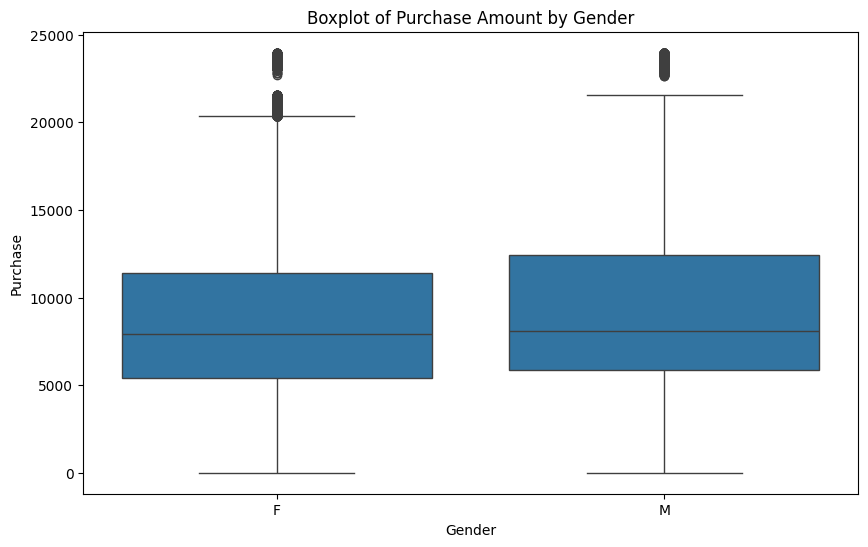

```python
plt.figure(figsize=(10, 6))
sns.boxplot(x='Gender', y='Purchase', data=data)
plt.title('Boxplot of Purchase Amount by Gender')
plt.show()
```

## Data exploration

```python
# Calculate total number of purchases
total_purchases = len(data)
print(f'Total Number of Purchases: {total_purchases}')
```

```
Total Number of Purchases: 550068
```

```python
# Calculate the total number of unique User_IDs
unique_user_ids = data['User_ID'].nunique()
print(f'Unique users count: {unique_user_ids}')
```

```
Unique users count: 5891
```

```python
# Calculate average number of purchases per user
average_purchases_per_user = data.groupby('User_ID').size().mean()
print(f'Average Number of Purchases per User: {average_purchases_per_user}')
```

```
Average Number of Purchases per User: 93.37429977932439
```

```python
# Calculate total and average number of purchases for female customers
total_purchases_female = len(data[data['Gender'] == 'F'])
average_purchases_per_female_user = data[data['Gender'] == 'F'].groupby('User_ID').size().mean()
print(f'Total Number of Purchases for Female Customers: {total_purchases_female}')
print(f'Average Number of Purchases per Female User: {average_purchases_per_female_user}')
```

```
Total Number of Purchases for Female Customers: 135809
Average Number of Purchases per Female User: 81.51800720288115
```

```python
# Calculate total and average number of purchases for male customers
total_purchases_male = len(data[data['Gender'] == 'M'])
average_purchases_per_male_user = data[data['Gender'] == 'M'].groupby('User_ID').size().mean()
print(f'Total Number of Purchases for Male Customers: {total_purchases_male}')
print(f'Average Number of Purchases per Male User: {average_purchases_per_male_user}')
```

```
Total Number of Purchases for Male Customers: 414259
Average Number of Purchases per Male User: 98.0494674556213
```

```python
# Calculate total purchase amount
total_purchase = data['Purchase'].sum()
print(f'Total Purchase Amount: {total_purchase}')
```

```
Total Purchase Amount: 5095812742
```

```python
# Calculate average purchase amount per user
average_purchase_per_user = data.groupby('User_ID')['Purchase'].mean().mean()
print(f'Average Purchase Amount per User: {average_purchase_per_user}')
```

```
Average Purchase Amount per User: 9568.83991355893
```

```python
# Calculate total and average purchase amount for female customers
total_purchase_female = data[data['Gender'] == 'F']['Purchase'].sum()
average_purchase_per_female_user = data[data['Gender'] == 'F'].groupby('User_ID')['Purchase'].mean().mean()
print(f'Total Purchase Amount for Female Customers: {total_purchase_female}')
print(f'Average Purchase Amount per Female User: {average_purchase_per_female_user}')
```

```
Total Purchase Amount for Female Customers: 1186232642
Average Purchase Amount per Female User: 8965.19846393646
```

```python
# Calculate total and average purchase amount for male customers
total_purchase_male = data[data['Gender'] == 'M']['Purchase'].sum()
average_purchase_per_male_user = data[data['Gender'] == 'M'].groupby('User_ID')['Purchase'].mean().mean()
print(f'Total Purchase Amount for Male Customers: {total_purchase_male}')
print(f'Average Purchase Amount per Male User: {average_purchase_per_male_user}')
```

```
Total Purchase Amount for Male Customers: 3909580100
Average Purchase Amount per Male User: 9806.867524226629
```

```python
#replacing the values in marital_status column

data['Marital_Status'] = data['Marital_Status'].replace({0:'Unmarried',1:'Married'})
data['Marital_Status'].unique()
```

```
array(['Unmarried', 'Married'], dtype=object)
```

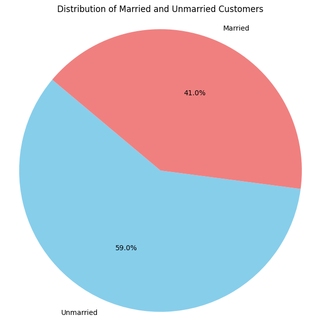

```python
# Calculate the number of male and female customers
marital_status_counts = data['Marital_Status'].value_counts()

# Plot the pie chart
plt.figure(figsize=(8, 8))
plt.pie(marital_status_counts, labels=marital_status_counts.index, autopct='%1.1f%%', startangle=140, colors=['skyblue', 'lightcoral'])
plt.title('Distribution of Married and Unmarried Customers')
plt.axis('equal')  # Equal aspect ratio ensures that pie is drawn as a circle.
plt.show()
```

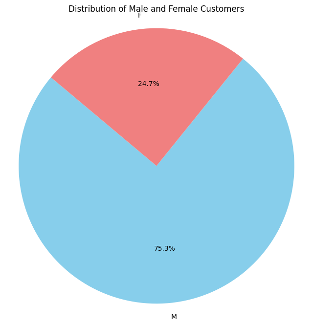

```python
# Calculate the number of married and unmarried customers
gender_counts = data['Gender'].value_counts()

# Plot the pie chart
plt.figure(figsize=(8, 8))
plt.pie(gender_counts, labels=gender_counts.index, autopct='%1.1f%%', startangle=140, colors=['skyblue', 'lightcoral'])
plt.title('Distribution of Male and Female Customers')
plt.axis('equal')  # Equal aspect ratio ensures that pie is drawn as a circle.
plt.show()
```

```python
# Calculate the average purchase amount for male and female customers
average_purchase_female = data[data['Gender'] == 'F']['Purchase'].mean()
average_purchase_male = data[data['Gender'] == 'M']['Purchase'].mean()

print(f'Average Purchase Amount for Female: {average_purchase_female}')
print(f'Average Purchase Amount for Male: {average_purchase_male}')
```

```
Average Purchase Amount for Female: 8734.565765155476
Average Purchase Amount for Male: 9437.526040472265
```

```python
data.head()
```

|  | User_ID | Product_ID | Gender | Age | Occupation | City_Category | Stay_In_Current_City_Years | Marital_Status | Product_Category | Purchase |
| --- | --- | --- | --- | --- | --- | --- | --- | --- | --- | --- |
| 0 | 1000001 | P00069042 | F | 0-17 | 10 | A | 2 | Unmarried | 3 | 8370 |
| 1 | 1000001 | P00248942 | F | 0-17 | 10 | A | 2 | Unmarried | 1 | 15200 |
| 2 | 1000001 | P00087842 | F | 0-17 | 10 | A | 2 | Unmarried | 12 | 1422 |
| 3 | 1000001 | P00085442 | F | 0-17 | 10 | A | 2 | Unmarried | 12 | 1057 |
| 4 | 1000002 | P00285442 | M | 55+ | 16 | C | 4+ | Unmarried | 8 | 7969 |

```python
data['User_ID'].value_counts()
```

```
User_ID
1001680    1026
1004277     979
1001941     898
1001181     862
1000889     823
           ...
1002690       7
1002111       7
1005810       7
1004991       7
1000708       6
Name: count, Length: 5891, dtype: int64
```

```python
data['Product_ID'].value_counts()
```

```
Product_ID
P00265242    1880
P00025442    1615
P00110742    1612
P00112142    1562
P00057642    1470
             ...
P00314842       1
P00298842       1
P00231642       1
P00204442       1
P00066342       1
Name: count, Length: 3631, dtype: int64
```

```python
data['Gender'].value_counts()
```

```
Gender
M    414259
F    135809
Name: count, dtype: int64
```

```python
data['Age'].value_counts()
```

```
Age
26-35    219587
36-45    110013
18-25     99660
46-50     45701
51-55     38501
55+       21504
0-17      15102
Name: count, dtype: int64
```

```python
data['Occupation'].value_counts()
```

```
Occupation
4     72308
0     69638
7     59133
1     47426
17    40043
20    33562
12    31179
14    27309
2     26588
16    25371
6     20355
3     17650
10    12930
5     12177
15    12165
11    11586
19     8461
13     7728
18     6622
9      6291
8      1546
Name: count, dtype: int64
```

```python
data['City_Category'].value_counts()
```

```
City_Category
B    231173
C    171175
A    147720
Name: count, dtype: int64
```

```python
data['Stay_In_Current_City_Years'].value_counts()
```

```
Stay_In_Current_City_Years
1     193821
2     101838
3      95285
4+     84726
0      74398
Name: count, dtype: int64
```

```python
data['Marital_Status'].value_counts()
```

```
Marital_Status
Unmarried    324731
Married      225337
Name: count, dtype: int64
```

```python
data['Product_Category'].value_counts()
```

```
Product_Category
5     150933
1     140378
8     113925
11     24287
2      23864
6      20466
3      20213
4      11753
16      9828
15      6290
13      5549
10      5125
12      3947
7       3721
18      3125
20      2550
19      1603
14      1523
17       578
9        410
Name: count, dtype: int64
```

```python
data['Purchase'].value_counts()
```

```
Purchase
7011     191
7193     188
6855     187
6891     184
7012     183
        ...
23491      1
18345      1
3372       1
855        1
21489      1
Name: count, Length: 18105, dtype: int64
```

## Univariate Analysis

```python
category = ['Age', 'Occupation', 'City_Category', 'Stay_In_Current_City_Years', 'Marital_Status', 'Product_Category']
```

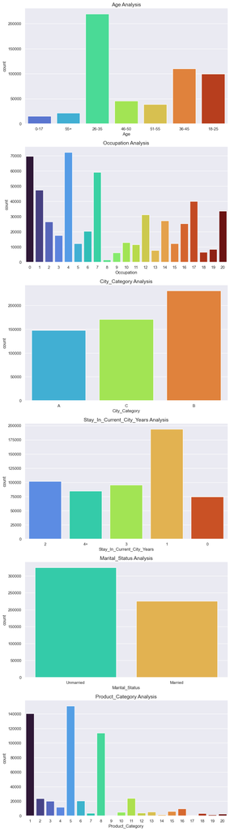

```python
plt.figure(figsize=(10,40))
sns.set(style='darkgrid')

# Plot each categorical column
for i, col in enumerate(category, 1):
    plt.subplot(6, 1, i)
    sns.countplot(data=data, x=col, hue=col, palette='turbo', legend=False)
    sns.despine()
    plt.title(f'{col} Analysis', fontsize=14, fontfamily='sans-serif')

# Show the plot
plt.show()
```

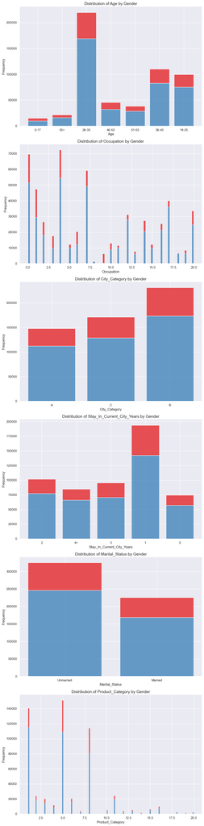

```python
plt.figure(figsize=(10, 40))
sns.set(style='darkgrid')

# Plot each categorical column
for i, col in enumerate(category, 1):
    plt.subplot(6, 1, i)
    sns.histplot(data=data, x=col, hue='Gender', palette='Set1', legend=False, multiple='stack', shrink=0.8)
    sns.despine()

    # Set labels and title
    plt.xlabel(f'{col}', fontsize=12)
    plt.ylabel('Frequency', fontsize=12)
    plt.title(f'Distribution of {col} by Gender', fontsize=14, fontfamily='sans-serif')

    plt.tight_layout()

plt.show()
```

## Multivariate Analysis

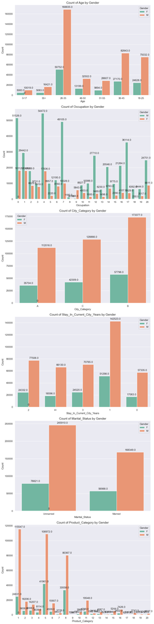

```python
plt.figure(figsize=(10, 40))
sns.set(style='darkgrid')

# Plot each categorical column
for i, col in enumerate(category, 1):
    plt.subplot(6, 1, i)
    ax = sns.countplot(data=data, x=col, hue='Gender', palette='Set2')
    sns.despine()

    plt.title(f'Count of {col} by Gender', fontsize=14, fontfamily='sans-serif')
    plt.xlabel(col)
    plt.ylabel('Count')

    # Add bar counts as text labels
    for p in ax.patches:
        ax.annotate(f'{p.get_height()}',
                    (p.get_x() + p.get_width() / 2.,
                     p.get_height()),
                    ha='center',
                    va='center',
                    xytext=(0, 10),
                    textcoords='offset points')

    plt.tight_layout()

plt.show()
```

## Insights

**Note:** Among 550068 transactions there are 5891 unique user_id, indicating same customers buying multiple products.

**Note:** Among 550068 transactions there are 3631 unique products,with the product having the code P00265242 being the highest seller, with a maximum of 1,880 units sold.

**Note:** Out of 550068 transactions, 414259 (nearly 75%) were done by male gender indicating a significant disparity in purchase behavior between males and females during the Black Friday event.

**Note:** We have 7 unique age groups in the dataset. 26 - 35 Age group has maximum of 219587 transactions

**Note:** Stay_In_Current_City_Years - Customers with 1 year of stay in current city accounted to maximum of 193821 transactions among all the other customers with (0,2,3,4+) years of stay in current city

**Note:** Marital_Status - 59% of the total transactions were done by Unmarried Customers and 41% by Married Customers.

**Note:** Customers with Occupation '4' has the highest purchase, and Occupations '0', '7', and '1' also have significant counts.

**Note:** City_Category 'B' has the most purchases. City_Category 'C' and 'A' follow in terms of count.

**Note:** Product categories '1' and '5' has higher purchase amounts, indicating that these categories contribute significantly to the overall sales revenue.

```python
data.info()
```

```
<class 'pandas.core.frame.DataFrame'>
RangeIndex: 550068 entries, 0 to 550067
Data columns (total 10 columns):
 #   Column                      Non-Null Count   Dtype
---  ------                      --------------   -----
 0   User_ID                     550068 non-null  int64
 1   Product_ID                  550068 non-null  object
 2   Gender                      550068 non-null  object
 3   Age                         550068 non-null  object
 4   Occupation                  550068 non-null  int64
 5   City_Category               550068 non-null  object
 6   Stay_In_Current_City_Years  550068 non-null  object
 7   Marital_Status              550068 non-null  object
 8   Product_Category            550068 non-null  int64
 9   Purchase                    550068 non-null  int64
dtypes: int64(4), object(6)
memory usage: 42.0+ MB
```

```python
data["User_ID"] = data["User_ID"].astype('category')
data["Occupation"] = data["Occupation"].astype('category')
data["Product_Category"] = data["Product_Category"].astype('category')
```

```python
data.info()
```

```
<class 'pandas.core.frame.DataFrame'>
RangeIndex: 550068 entries, 0 to 550067
Data columns (total 10 columns):
 #   Column                      Non-Null Count   Dtype
---  ------                      --------------   -----
 0   User_ID                     550068 non-null  category
 1   Product_ID                  550068 non-null  object
 2   Gender                      550068 non-null  object
 3   Age                         550068 non-null  object
 4   Occupation                  550068 non-null  category
 5   City_Category               550068 non-null  object
 6   Stay_In_Current_City_Years  550068 non-null  object
 7   Marital_Status              550068 non-null  object
 8   Product_Category            550068 non-null  category
 9   Purchase                    550068 non-null  int64
dtypes: category(3), int64(1), object(6)
memory usage: 31.6+ MB
```

```python
data.describe()
```

|  | Purchase |
| --- | --- |
| count | 550068.000000 |
| mean | 9263.968713 |
| std | 5023.065394 |
| min | 12.000000 |
| 25% | 5823.000000 |
| 50% | 8047.000000 |
| 75% | 12054.000000 |
| max | 23961.000000 |

```python
data.groupby('Gender')['Purchase'].describe().T
```

| Gender | F | M |
| --- | --- | --- |
| count | 135809.000000 | 414259.00000 |
| mean | 8734.565765 | 9437.52604 |
| std | 4767.233289 | 5092.18621 |
| min | 12.000000 | 12.00000 |
| 25% | 5433.000000 | 5863.00000 |
| 50% | 7914.000000 | 8098.00000 |
| 75% | 11400.000000 | 12454.00000 |
| max | 23959.000000 | 23961.00000 |

**Note:** The purchase amounts vary widely, with the minimum recorded purchase being 12 and the maximum reaching to 23961. The median purchase amount of 8047 is notably lower than the mean purchase amount of 9264, indicating a right-skewed distribution where a few high-value purchases pull up the mean

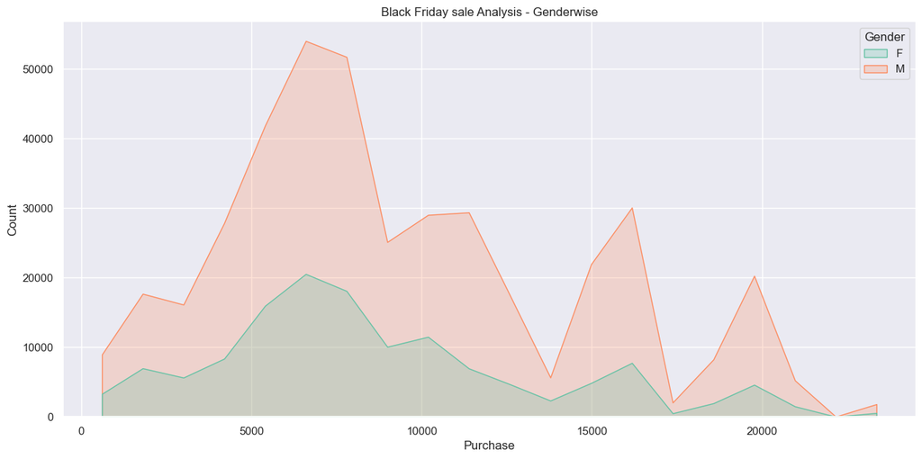

```python
plt.figure(figsize=(15,7))
sns.set(style='darkgrid')
sns.histplot(data=data, x = "Purchase", bins=20, hue = "Gender",element='poly',palette= 'Set2')
sns.despine()
plt.title('Black Friday sale Analysis - Genderwise')
plt.show()
```

**Note:** The total number of male customers (4225) exceeds the total number of female customers (1666).

**Note:** The average amount spent by male customers (9437) is higher than the average amount spent by female customers (8734).

**Note:** With a larger male customer base, it is likely that men will make more purchases compared to females.

**Note:** The higher sales among male customers could be attributed to a product range better suited to their preferences, leading to increased sales of products targeted towards men.

## Use the sample average to find out the confidence interval

```python
# For female customers
sample_female = data[data['Gender'] == 'F']['Purchase']
mean_female = np.mean(sample_female)
std_female = np.std(sample_female, ddof=1)
n_female = len(sample_female)
confidence_level = 0.95
z_score = stats.norm.ppf(1 - (1 - confidence_level) / 2)
margin_of_error_female = z_score * (std_female / np.sqrt(n_female))
ci_female = (mean_female - margin_of_error_female, mean_female + margin_of_error_female)

print(f'95% Confidence Interval for Female Purchase Amount: {ci_female}')
```

```
95% Confidence Interval for Female Purchase Amount: (8709.21154714068, 8759.919983170272)
```

```python
# For male customers
sample_male = data[data['Gender'] == 'M']['Purchase']
mean_male = np.mean(sample_male)
std_male = np.std(sample_male, ddof=1)
n_male = len(sample_male)
margin_of_error_male = z_score * (std_male / np.sqrt(n_male))
ci_male = (mean_male - margin_of_error_male, mean_male + margin_of_error_male)

print(f'95% Confidence Interval for Male Purchase Amount: {ci_male}')
```

```
95% Confidence Interval for Male Purchase Amount: (9422.01944736257, 9453.032633581959)
```

## Compare the confidence intervals

```python
if (ci_female[0] <= ci_male[1] and ci_female[1] >= ci_male[0]):
    print("The confidence intervals for male and female purchase amounts overlap.")
else:
    print("The confidence intervals for male and female purchase amounts do not overlap.")
```

```
The confidence intervals for male and female purchase amounts do not overlap.
```

```python
# Calculate the average purchase amount for married and unmarried customers
average_purchase_married = data[data['Marital_Status'] == 1]['Purchase'].mean()
average_purchase_unmarried = data[data['Marital_Status'] == 0]['Purchase'].mean()

print(f'Average Purchase Amount for Married: {average_purchase_married}')
print(f'Average Purchase Amount for Unmarried: {average_purchase_unmarried}')
```

```
Average Purchase Amount for Married: nan
Average Purchase Amount for Unmarried: nan
```

```python
# For married customers
sample_married = data[data['Marital_Status'] == 1]['Purchase']
mean_married = np.mean(sample_married)
std_married = np.std(sample_married, ddof=1)
n_married = len(sample_married)
margin_of_error_married = z_score * (std_married / np.sqrt(n_married))
ci_married = (mean_married - margin_of_error_married, mean_married + margin_of_error_married)

print(f'95% Confidence Interval for Married Purchase Amount: {ci_married}')
```

```
95% Confidence Interval for Married Purchase Amount: (nan, nan)
```

```python
# For unmarried customers
sample_unmarried = data[data['Marital_Status'] == 0]['Purchase']
mean_unmarried = np.mean(sample_unmarried)
std_unmarried = np.std(sample_unmarried, ddof=1)
n_unmarried = len(sample_unmarried)
margin_of_error_unmarried = z_score * (std_unmarried / np.sqrt(n_unmarried))
ci_unmarried = (mean_unmarried - margin_of_error_unmarried, mean_unmarried + margin_of_error_unmarried)

print(f'95% Confidence Interval for Unmarried Purchase Amount: {ci_unmarried}')
```

```
95% Confidence Interval for Unmarried Purchase Amount: (nan, nan)
```

## Analysis for Age groups

```python
data["AgeGroup"] = data["Age"]
```

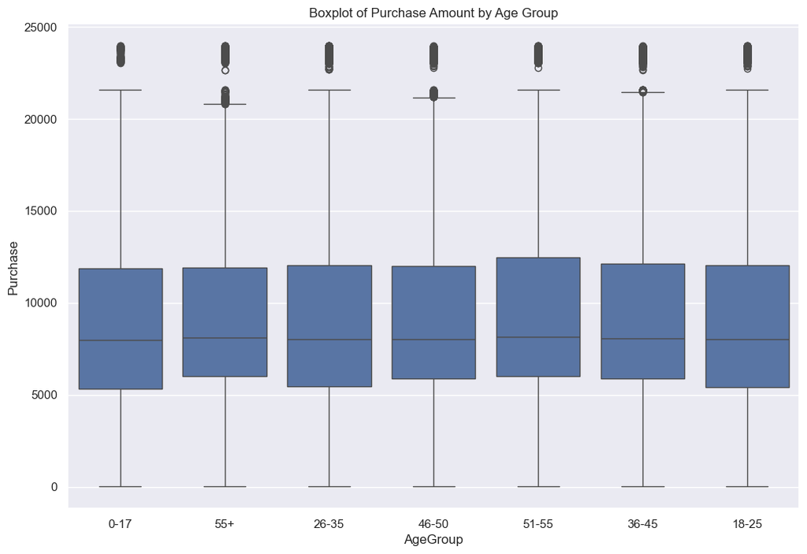

```python
# Plot the distribution of purchase amounts by Age Group
plt.figure(figsize=(12, 8))
sns.boxplot(x='AgeGroup', y='Purchase', data=data)
plt.title('Boxplot of Purchase Amount by Age Group')
plt.show()
```

```python
# Calculate average purchase for each age group
age_group_means = data.groupby('AgeGroup')['Purchase'].mean()
print(age_group_means)
```

```
AgeGroup
0-17     8933.464640
18-25    9169.663606
26-35    9252.690633
36-45    9331.350695
46-50    9208.625697
51-55    9534.808031
55+      9336.280459
Name: Purchase, dtype: float64
```

# Recommendations for Walmart

Recommendations:

1. Age Group Targeting: Concentrate marketing efforts on individuals aged 26-35, as they show the highest purchase rates. Design promotions and advertisements to appeal to this demographic.
2. Occupation-Specific Offers: Since occupation category '4' has the highest representation and significant purchases, customize product offerings or promotions to cater to individuals in this occupation.
3. City Category Focus: Allocate promotional resources strategically with an emphasis on City_Category 'B', where the highest purchase levels are observed. Tailor promotions to match the preferences of customers in this category.
4. Marital Status Campaigns: Launch targeted marketing campaigns for single individuals, as they contribute significantly more to overall sales. Understand and cater to the preferences of this demographic.
5. Loyalty Programs: Develop strategies to encourage customers to stay in their current city for more than a year. Consider loyalty programs or special incentives for long-term residents to boost their purchasing behavior.
6. Product Category Optimization: Optimize inventory and promotions for product categories '1' and '5', as they show higher purchase amounts. Manage these categories strategically to maximize overall sales revenue.
7. Gender-Targeted Marketing: Implement gender-targeted marketing strategies, especially focusing on males across various age groups. Use insights from age-based gender analysis to tailor promotions effectively.
8. Top Occupation Incentives: Design promotions or incentives based on the top occupations, such as '0' and '4', to further boost sales from these occupational groups.
9. City-Specific Initiatives: Implement specific initiatives, offers, or events in City_Category 'B' to capitalize on the higher purchasing behavior observed in this category.
10. Male Customer Preferences: Analyze the product preferences of male customers to inform product development. Ensure the product range aligns with the preferences of the larger male customer base to increase sales.
11. Female Customer Targeting: Develop marketing strategies to target female customers more effectively, especially around Black Friday.
12. Marital Status Spending Analysis: Investigate the spending patterns of married vs. unmarried customers to identify potential market opportunities.
13. Age-Specific Promotions: Focus on age-specific promotions and products to better cater to the needs of different age groups.
14. Spending Behavior Analysis: Conduct further analysis to explore the underlying factors contributing to spending differences between genders and marital statuses.
15. Expanded Dataset Analysis: Consider expanding the dataset to include other relevant features that may impact customer spending behavior.

# Action items for Walmart

Actionable Items:

1. Targeted Female Marketing Campaigns: Design and implement marketing campaigns specifically for female customers during peak shopping periods such as Black Friday.
2. Loyalty Programs for Married Customers: Develop loyalty programs or special discount offers to encourage higher spending among married customers.
3. Age-Specific Product Customization: Tailor product offerings and promotions for various age groups based on their distinct spending patterns.
4. Inventory and Product Placement Optimization: Utilize insights from the analysis to enhance inventory management and optimize product placement in stores.